# netflix_original_로버스트회귀

## Cooks distance outlier제거

종합데이터, 드라마데이터, 영화데이터를 가지고 outlier(이상치)를 제거하는 기준으로 cooks distance를 사용하였다.

### 종합 데이터

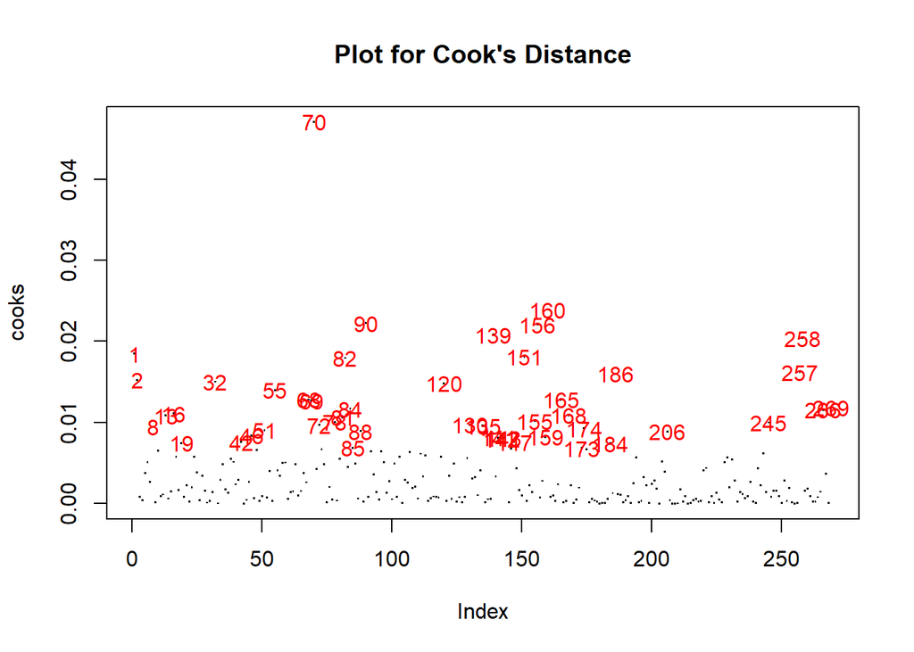

```r
fit_tmp <- lm(All_rating ~ . , data=netflix_original_success) #lm :  linear regression의 핵심으로, 회귀분석, 단일 계층 분석, 공분산 분석에 이용할 수 있다.
cooks <- cooks.distance(fit_tmp) # 일반회귀를 통해 cooks 값을 구한다.
plot(cooks, pch=".", cex=1.5, main = "Plot for Cook's Distance") # cooks 시각화
# plot() 함수는 x, y 인자 2개를 기본적으로 받습니다.
# cex : 기호의 크기를 지정할 때 사용 cex에 입력하는 숫자는 디폴트인 cex=1 대비 상대적인 크기를 나타냄.

text(x=1:length(cooks), y=cooks, labels = ifelse(cooks > 4/nrow(netflix), names(cooks), ""), col = "red") # 어떤 데이터인지 plot에 표시
```

```r
outlier <- names(cooks)[(cooks > 4/nrow(netflix_original_success))] # outlier기준: 4/(sample size)를 넘는 cooks값을 가진 데이터
outlier <- as.integer(na.omit(outlier))
netflix_original_success <- netflix_original_success[-outlier, ] # oulier로 판정된 데이터 제거
```

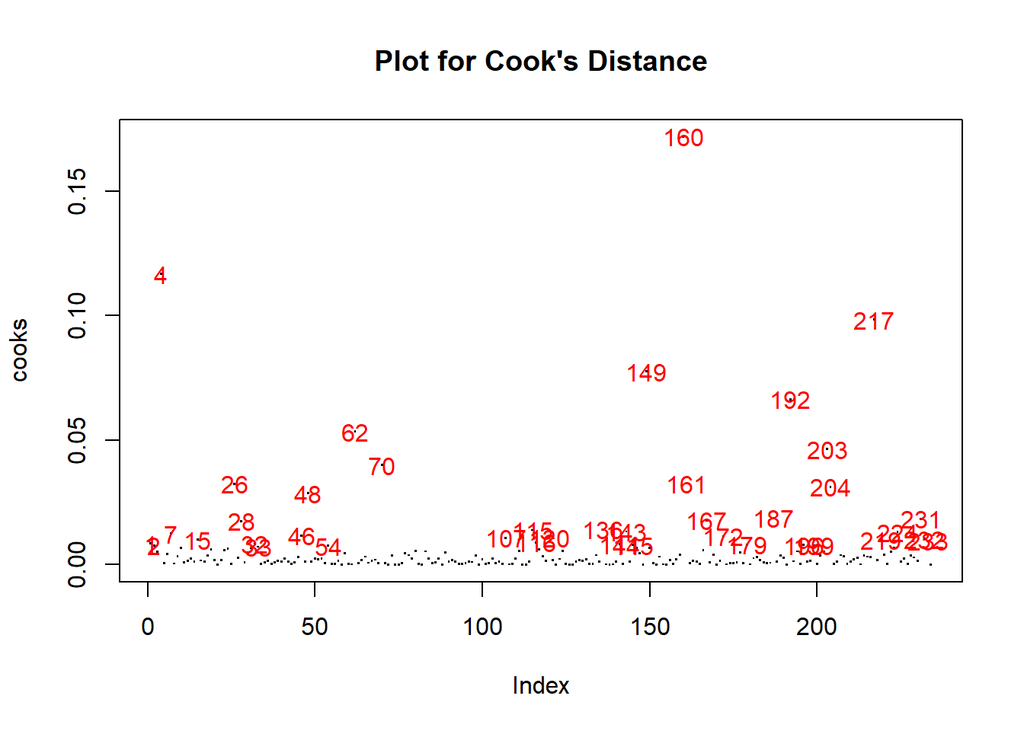

```r
fit_tmp <- lm(All_rating ~ . , data=netflix_original_failure)
cooks <- cooks.distance(fit_tmp)
plot(cooks, pch=".", cex=1.5, main = "Plot for Cook's Distance")

text(x=1:length(cooks), y=cooks, labels = ifelse(cooks > 4/nrow(netflix), names(cooks), ""), col = "red")
```

```r
outlier <- names(cooks)[(cooks > 4/nrow(netflix_original_failure))]
outlier <- as.integer(na.omit(outlier))
netflix_original_failure <- netflix_original_failure[-outlier, ]
```

### 드라마 데이터

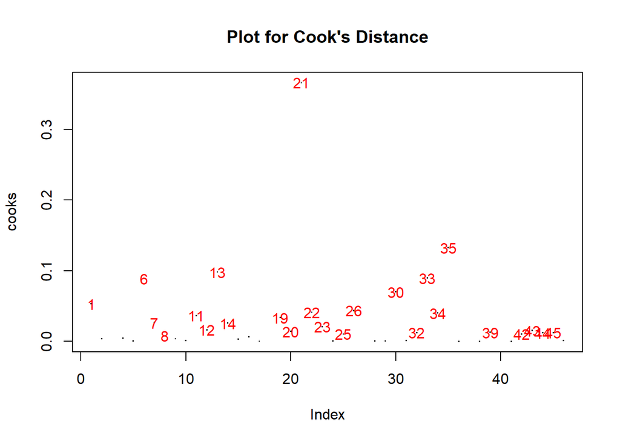

```r
fit_tmp <- lm(All_rating ~ . , data=netflix_drama_success)
cooks <- cooks.distance(fit_tmp)
plot(cooks, pch=".", cex=1.5, main = "Plot for Cook's Distance")

text(x=1:length(cooks), y=cooks, labels = ifelse(cooks > 4/nrow(netflix), names(cooks), ""), col = "red")
```

```r
outlier <- names(cooks)[(cooks > 4/nrow(netflix_drama_success))]
outlier <- as.integer(na.omit(outlier))
netflix_drama_success <- netflix_drama_success[-outlier, ]
```

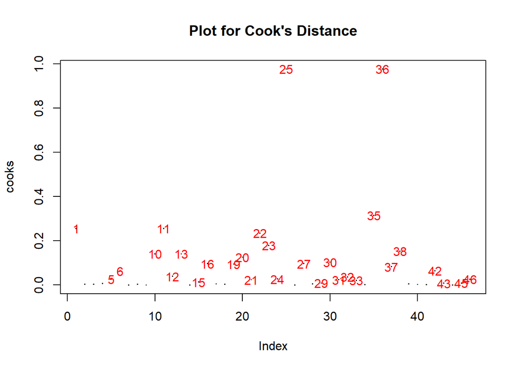

```r
fit_tmp <- lm(All_rating ~ . , data=netflix_drama_failure)
cooks <- cooks.distance(fit_tmp)
plot(cooks, pch=".", cex=1.5, main = "Plot for Cook's Distance")

text(x=1:length(cooks), y=cooks, labels = ifelse(cooks > 4/nrow(netflix), names(cooks), ""), col = "red")
```

```r
outlier <- names(cooks)[(cooks > 4/nrow(netflix_drama_failure))]
outlier <- as.integer(na.omit(outlier))
netflix_drama_failure <- netflix_drama_failure[-outlier, ]
```

### 영화 데이터

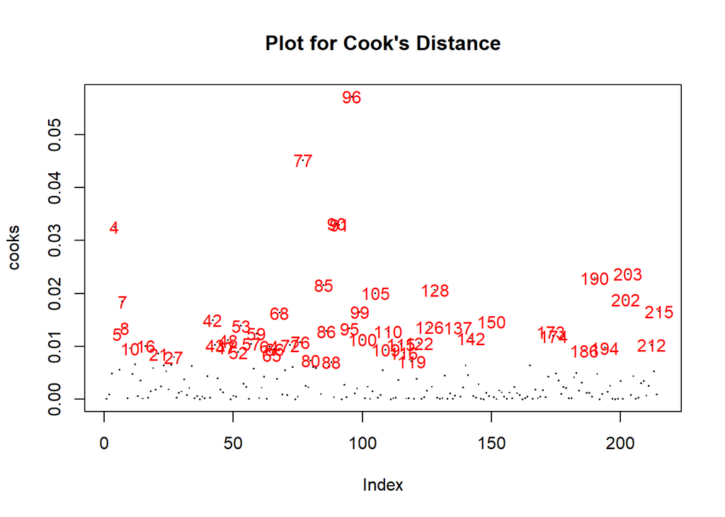

```r
fit_tmp <- lm(All_rating ~ . , data=netflix_movie_success)
cooks <- cooks.distance(fit_tmp)
plot(cooks, pch=".", cex=1.5, main = "Plot for Cook's Distance")

text(x=1:length(cooks), y=cooks, labels = ifelse(cooks > 4/nrow(netflix), names(cooks), ""), col = "red")
```

```r
outlier <- names(cooks)[(cooks > 4/nrow(netflix_movie_success))]
outlier <- as.integer(na.omit(outlier))
netflix_movie_success <- netflix_movie_success[-outlier, ]
```

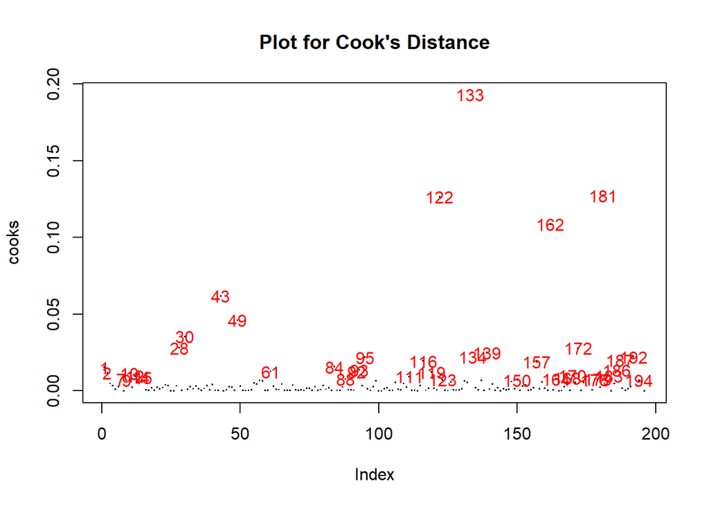

```r
fit_tmp <- lm(All_rating ~ . , data=netflix_movie_failure)
cooks <- cooks.distance(fit_tmp)
plot(cooks, pch=".", cex=1.5, main = "Plot for Cook's Distance")

text(x=1:length(cooks), y=cooks, labels = ifelse(cooks > 4/nrow(netflix), names(cooks), ""), col = "red")
```

```r
outlier <- names(cooks)[(cooks > 4/nrow(netflix_movie_failure))]
outlier <- as.integer(na.omit(outlier))
netflix_movie_failure <- netflix_movie_failure[-outlier, ]
```

## 일반회귀

### 종합 데이터(성공)

#### 세부 factor에서 유의한 값

Estimate , Std. Error, t value, Pr(>|t|) 를 확인하고, 유의미한 정도를 *의 개수를 통해 확인할 수 있다.

```r
fit_OLS_original_success <- lm(All_rating ~ . , data=netflix_original_success)
summary(fit_OLS_original_success) # Summary() 함수는 중심화 경향과 퍼짐정도에 대해서 quick 하게 볼 수 있는 통계량들을 제공합니다.
```

```
Call:
lm(formula = All_rating ~ ., data = netflix_original_success)

Residuals:
     Min       1Q   Median       3Q      Max
-1.13624 -0.35268 -0.03818  0.29197  1.25953

Coefficients:
                         Estimate Std. Error t value Pr(>|t|)
(Intercept)             7.7224976  0.5338166  14.467   <2e-16 ***
Mean_Length            -0.0005807  0.0010266  -0.566   0.5722
Director_max_award      0.0023731  0.0012621   1.880   0.0614 .
Year2014               -0.1167968  0.5609371  -0.208   0.8352
Year2015               -0.1670051  0.5680242  -0.294   0.7690
Year2016               -0.1347321  0.5371438  -0.251   0.8022
Year2017               -0.3321044  0.5226577  -0.635   0.5258
Year2018               -0.4682878  0.5212079  -0.898   0.3699
Year2019               -0.3299564  0.5204217  -0.634   0.5267
Year2020               -0.3164902  0.5251000  -0.603   0.5473
Harmful_themes높음     -0.6347145  0.2019922  -3.142   0.0019 **
Harmful_themes다소높음 -0.3707435  0.1658684  -2.235   0.0264 *
Harmful_themes보통     -0.2839916  0.1637964  -1.734   0.0843 .
Lewdness높음            0.3005356  0.1363422   2.204   0.0285 *
Lewdness다소높음       -0.0014184  0.1063184  -0.013   0.9894
Lewdness보통            0.1152443  0.1161069   0.993   0.3220
Violence높음            0.0864753  0.1554083   0.556   0.5785
Violence다소높음        0.0234184  0.1070640   0.219   0.8271
Violence보통            0.0288299  0.1060128   0.272   0.7859
Profanity높음           0.1848568  0.1963425   0.942   0.3475
Profanity다소높음       0.2364657  0.1472947   1.605   0.1098
Profanity보통           0.1678124  0.1330518   1.261   0.2085
Fear높음                0.3927845  0.1527497   2.571   0.0108 *
Fear다소높음            0.1447115  0.1192102   1.214   0.2261
Fear보통                0.0392998  0.0978392   0.402   0.6883
Drugs높음               0.1428756  0.1543868   0.925   0.3557
Drugs다소높음          -0.0553327  0.1144084  -0.484   0.6291
Drugs보통              -0.0723893  0.1048757  -0.690   0.4908
Immatatable높음        -0.0032708  0.1580708  -0.021   0.9835
Immatatable다소높음    -0.1761854  0.1048101  -1.681   0.0942 .
Immatatable보통        -0.1173400  0.1135432  -1.033   0.3025
---
Signif. codes:  0 '***' 0.001 '**' 0.01 '*' 0.05 '.' 0.1 ' ' 1

Residual standard error: 0.5004 on 225 degrees of freedom
Multiple R-squared:  0.2034,    Adjusted R-squared:  0.09719
F-statistic: 1.915 on 30 and 225 DF,  p-value: 0.004306
```

#### 유의한 factor

ANOVA는 하나 이상의 범주 형 독립 변수 수준에 따라 양적 종속 변수 가 어떻게 변하는 지 추정하기위한 통계 검정 입니다.

ANOVA 는 독립 변수의 각 수준에서 그룹 평균 에 차이가 있는지 여부를 테스트합니다. 변량 분석. 3개이상 다수 집단을 비교할 때 사용하는 가설검정 방법으로, 다수간의 평균 비교에서 ANOVA를 통해 유의한 차이를 검정

```r
anova(fit_OLS_original_success) # 유의한 factor를 확인하기 위해 ANOVA함수를 이용함
```

```
Analysis of Variance Table

Response: All_rating
                    Df Sum Sq Mean Sq F value  Pr(>F)
Mean_Length          1  0.581 0.58064  2.3193 0.12919
Director_max_award   1  0.711 0.71102  2.8400 0.09333 .
Year                 7  1.312 0.18736  0.7484 0.63120
Harmful_themes       3  2.140 0.71333  2.8493 0.03829 *
Lewdness             3  2.762 0.92062  3.6773 0.01290 *
Violence             3  1.787 0.59555  2.3788 0.07060 .
Profanity            3  0.366 0.12202  0.4874 0.69139
Fear                 3  2.654 0.88477  3.5341 0.01558 *
Drugs                3  1.177 0.39249  1.5677 0.19804
Immatatable          3  0.894 0.29799  1.1903 0.31425
Residuals          225 56.330 0.25036
---
Signif. codes:  0 '***' 0.001 '**' 0.01 '*' 0.05 '.' 0.1 ' ' 1
```

#### 모델 유의성 확인

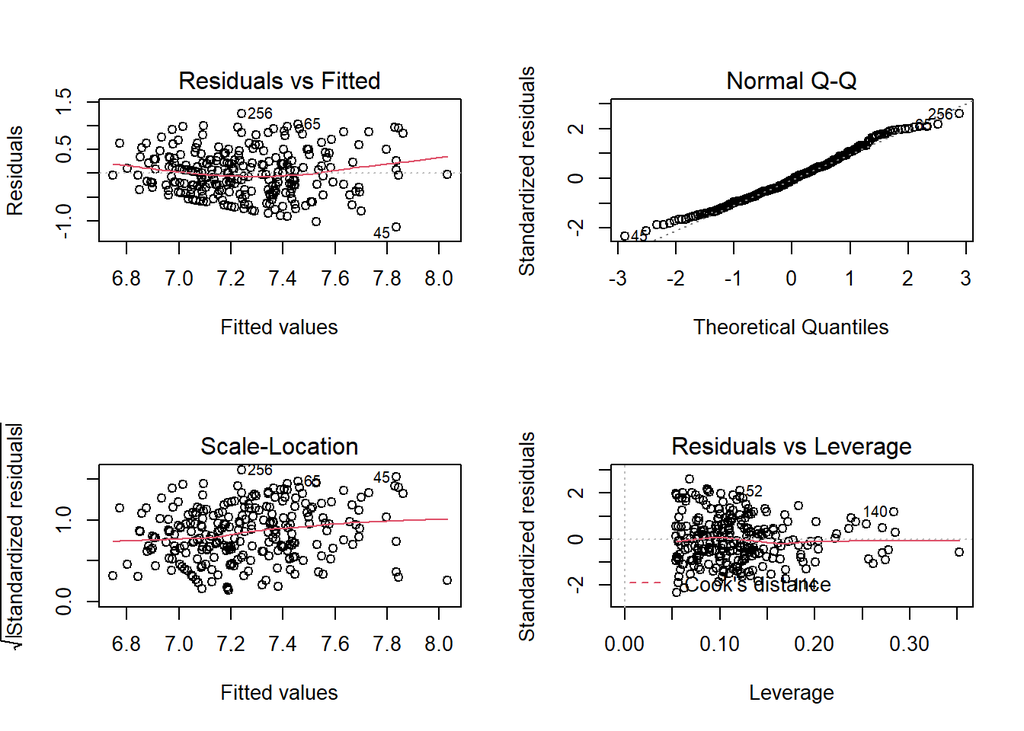

```r
par(mfrow = c(2,2)) # 한 화면에 여러 개의 그래프를 그려 비교하기 위해 par함수 사용
plot(fit_OLS_original_success) # fit_OLS_original의 그래프를 그려줌
```

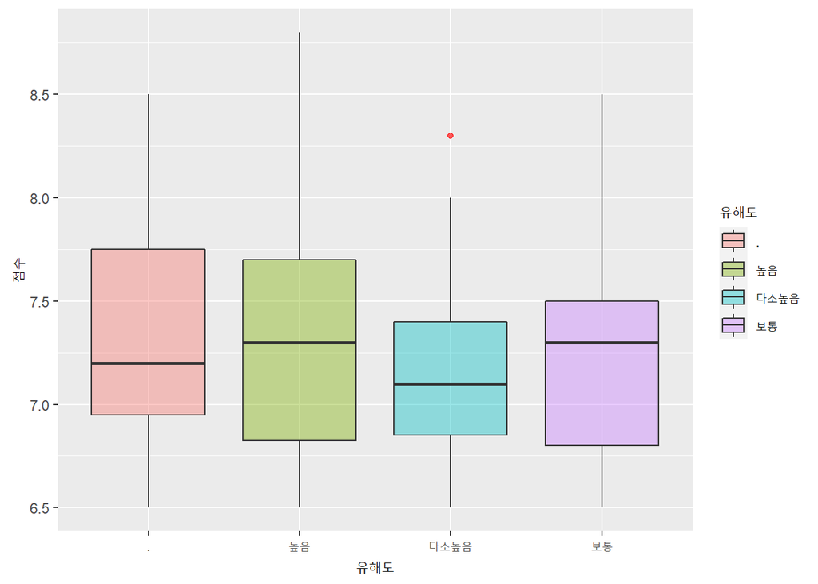

```r
library(ggplot2)
ggplot(netflix_original_success,aes(x=as.factor(Harmful_themes),y=All_rating))+
  geom_boxplot(aes(fill=as.factor(Harmful_themes)),outlier.colour = 'red',alpha=I(0.4))+
  xlab("유해도") + ylab("점수") + labs(fill = "유해도")
```

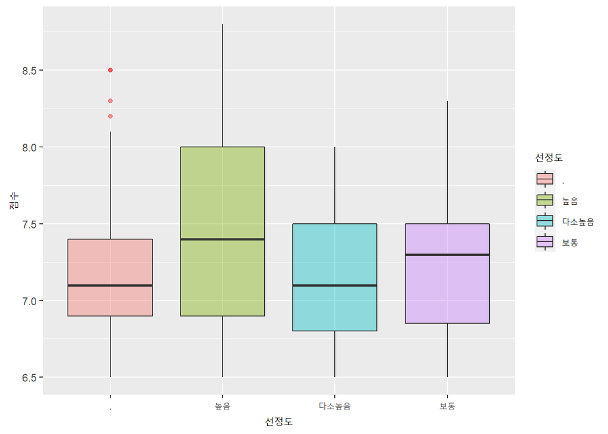

```r
ggplot(netflix_original_success,aes(x=as.factor(Lewdness),y=All_rating))+
  geom_boxplot(aes(fill=as.factor(Lewdness)),outlier.colour = 'red',alpha=I(0.4))+
  xlab("선정도") + ylab("점수") + labs(fill = "선정도")
```

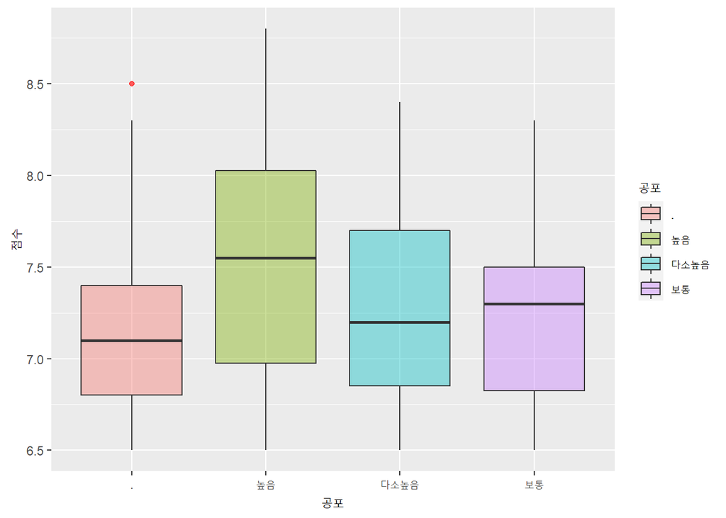

```r
ggplot(netflix_original_success,aes(x=as.factor(Fear),y=All_rating))+
  geom_boxplot(aes(fill=as.factor(Fear)),outlier.colour = 'red',alpha=I(0.4))+
  xlab("공포") + ylab("점수") + labs(fill = "공포")
```

### 종합 데이터(실패)

#### 세부 factor에서 유의한 값

```r
fit_OLS_original_failure <- lm(All_rating ~ . , data=netflix_original_failure)
summary(fit_OLS_original_failure)
```

```
Call:
lm(formula = All_rating ~ ., data = netflix_original_failure)

Residuals:
     Min       1Q   Median       3Q      Max
-1.41004 -0.22672  0.04808  0.31501  0.96167

Coefficients:
                        Estimate Std. Error t value Pr(>|t|)
(Intercept)             5.032694   0.427003  11.786  < 2e-16 ***
Mean_Length             0.002878   0.001387   2.076  0.03927 *
Director_max_award      0.004814   0.003417   1.409  0.16060
Year2016                0.660306   0.415828   1.588  0.11397
Year2017                0.771945   0.400904   1.926  0.05567 .
Year2018                0.706833   0.398229   1.775  0.07752 .
Year2019                0.582086   0.397920   1.463  0.14518
Year2020                0.743653   0.401393   1.853  0.06549 .
Harmful_themes높음     -0.089183   0.211428  -0.422  0.67364
Harmful_themes다소높음  0.041820   0.192253   0.218  0.82803
Harmful_themes보통     -0.367565   0.175490  -2.095  0.03755 *
Lewdness높음           -0.088419   0.126782  -0.697  0.48640
Lewdness다소높음       -0.291277   0.105504  -2.761  0.00633 **
Lewdness보통           -0.090979   0.111389  -0.817  0.41509
Violence높음           -0.110600   0.157672  -0.701  0.48388
Violence다소높음       -0.163353   0.118638  -1.377  0.17017
Violence보통           -0.136986   0.105132  -1.303  0.19416
Profanity높음          -0.144393   0.164712  -0.877  0.38179
Profanity다소높음      -0.041269   0.150184  -0.275  0.78378
Profanity보통          -0.021539   0.141312  -0.152  0.87902
Fear높음                0.277406   0.170792   1.624  0.10599
Fear다소높음           -0.090197   0.123885  -0.728  0.46747
Fear보통               -0.009842   0.119429  -0.082  0.93441
Drugs높음               0.169101   0.162535   1.040  0.29948
Drugs다소높음          -0.021726   0.125291  -0.173  0.86252
Drugs보통               0.111486   0.110777   1.006  0.31551
Immatatable높음         0.078319   0.145401   0.539  0.59077
Immatatable다소높음     0.037324   0.117964   0.316  0.75205
Immatatable보통         0.019967   0.131161   0.152  0.87917
---
Signif. codes:  0 '***' 0.001 '**' 0.01 '*' 0.05 '.' 0.1 ' ' 1

Residual standard error: 0.4966 on 189 degrees of freedom
Multiple R-squared:  0.2191,    Adjusted R-squared:  0.1034
F-statistic: 1.894 on 28 and 189 DF,  p-value: 0.006728
```

#### 유의한 factor

```r
anova(fit_OLS_original_failure)
```

```
Analysis of Variance Table

Response: All_rating
                    Df Sum Sq Mean Sq F value  Pr(>F)
Mean_Length          1  2.092 2.09185  8.4813 0.00402 **
Director_max_award   1  1.106 1.10616  4.4849 0.03550 *
Year                 5  1.966 0.39313  1.5939 0.16367
Harmful_themes       3  2.269 0.75627  3.0663 0.02922 *
Lewdness             3  1.779 0.59314  2.4048 0.06881 .
Violence             3  1.036 0.34541  1.4005 0.24406
Profanity            3  0.165 0.05484  0.2223 0.88080
Fear                 3  1.471 0.49042  1.9884 0.11717
Drugs                3  1.122 0.37407  1.5167 0.21159
Immatatable          3  0.072 0.02390  0.0969 0.96166
Residuals          189 46.615 0.24664
---
Signif. codes:  0 '***' 0.001 '**' 0.01 '*' 0.05 '.' 0.1 ' ' 1
```

#### 모델 유의성 확인

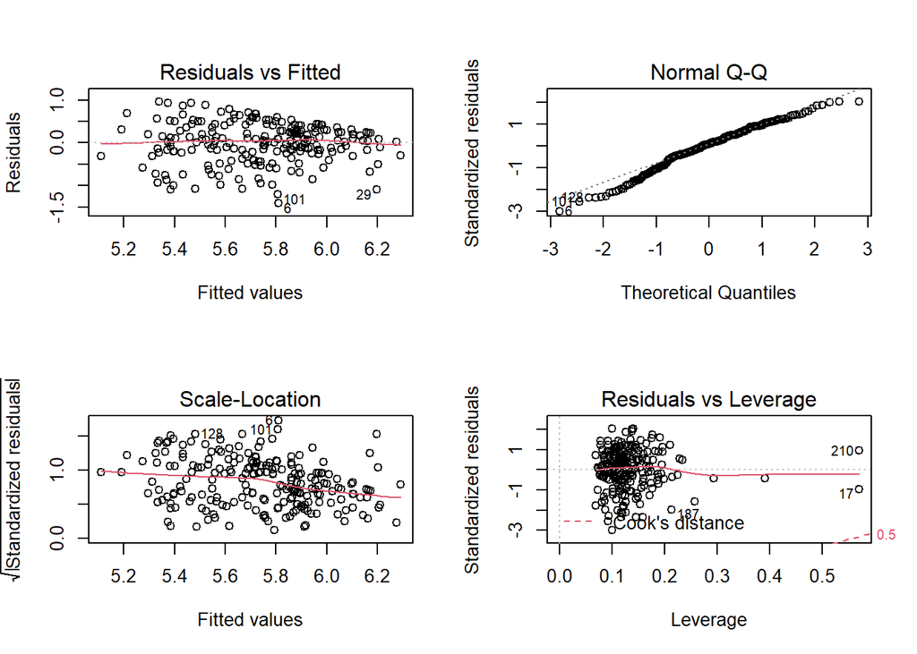

```r
par(mfrow = c(2,2)) # 한 화면에 여러 개의 그래프를 그려 비교하기 위해 par함수 사용
plot(fit_OLS_original_failure) # fit_OLS_original의 그래프를 그려줌
```

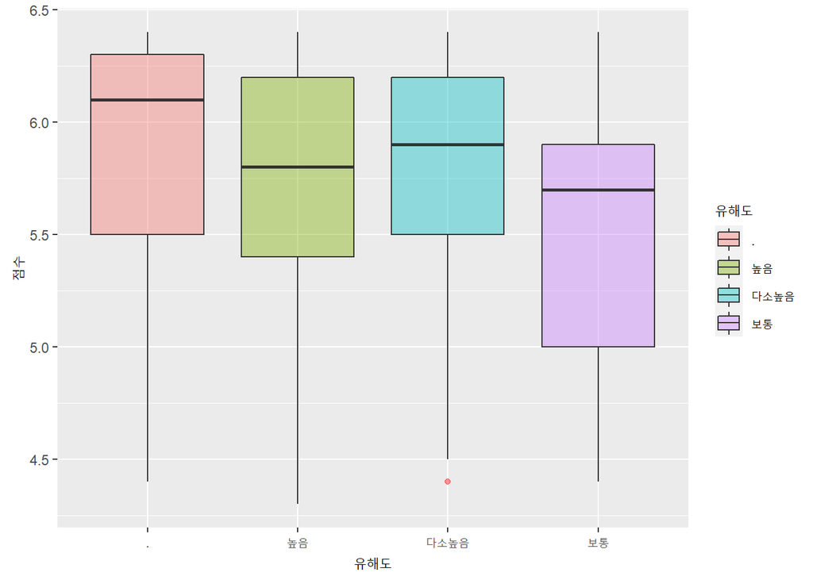

```r
ggplot(netflix_original_failure,aes(x=as.factor(Harmful_themes),y=All_rating))+
  geom_boxplot(aes(fill=as.factor(Harmful_themes)),outlier.colour = 'red',alpha=I(0.4))+
  xlab("유해도") + ylab("점수") + labs(fill = "유해도")
```

### 드라마 데이터(성공)

#### 세부 factor에서 유의한 값

```r
fit_OLS_drama_success <- lm(All_rating ~ . , data=netflix_drama_success)
summary(fit_OLS_drama_success)
```

```
Call:
lm(formula = All_rating ~ ., data = netflix_drama_success)

Residuals:
     Min       1Q   Median       3Q      Max
-0.39667 -0.08859  0.00000  0.07925  0.49856

Coefficients:
                        Estimate Std. Error t value Pr(>|t|)
(Intercept)             7.171483   0.578621  12.394 2.78e-09 ***
Mean_Length             0.001867   0.004956   0.377   0.7117
Director_max_award      0.008833   0.007588   1.164   0.2626
Year2016                0.168388   0.705653   0.239   0.8146
Year2017                0.848680   0.626490   1.355   0.1956
Year2018                0.910305   0.588736   1.546   0.1429
Year2019                0.381863   0.644734   0.592   0.5625
Year2020                0.601234   0.594507   1.011   0.3279
Harmful_themes높음      0.710759   0.672147   1.057   0.3070
Harmful_themes다소높음  0.525460   0.786961   0.668   0.5145
Harmful_themes보통     -0.893672   0.739561  -1.208   0.2456
Lewdness높음           -0.406390   0.550099  -0.739   0.4715
Lewdness다소높음       -0.252307   0.460493  -0.548   0.5918
Lewdness보통           -0.079071   0.519095  -0.152   0.8810
Violence높음           -0.545131   0.378448  -1.440   0.1703
Violence다소높음       -0.879230   0.396913  -2.215   0.0426 *
Violence보통           -0.839494   0.399625  -2.101   0.0530 .
Fear높음                1.291075   0.461883   2.795   0.0136 *
Fear다소높음            0.879107   0.447096   1.966   0.0681 .
Fear보통                0.849668   0.410183   2.071   0.0560 .
Drugs높음               0.494599   0.673945   0.734   0.4743
Drugs다소높음           0.735846   0.640904   1.148   0.2689
Drugs보통               0.360164   0.428026   0.841   0.4133
Immatatable높음        -1.016755   0.581635  -1.748   0.1009
Immatatable다소높음    -1.373761   0.661518  -2.077   0.0554 .
Immatatable보통         0.196890   0.609859   0.323   0.7513
---
Signif. codes:  0 '***' 0.001 '**' 0.01 '*' 0.05 '.' 0.1 ' ' 1

Residual standard error: 0.3225 on 15 degrees of freedom
Multiple R-squared:  0.7923,    Adjusted R-squared:  0.4462
F-statistic: 2.289 on 25 and 15 DF,  p-value: 0.04919
```

#### 유의한 factor

```r
anova(fit_OLS_drama_success)
```

```
Analysis of Variance Table

Response: All_rating
                   Df  Sum Sq Mean Sq F value   Pr(>F)
Mean_Length         1 0.17730 0.17730  1.7051 0.211295
Director_max_award  1 0.01589 0.01589  0.1528 0.701355
Year                5 2.40953 0.48191  4.6346 0.009327 **
Harmful_themes      3 0.74279 0.24760  2.3812 0.110370
Lewdness            3 0.10986 0.03662  0.3522 0.788200
Violence            3 1.10158 0.36719  3.5313 0.040881 *
Fear                3 0.53059 0.17686  1.7009 0.209544
Drugs               3 0.20545 0.06848  0.6586 0.590082
Immatatable         3 0.65754 0.21918  2.1079 0.142115
Residuals          15 1.55971 0.10398
---
Signif. codes:  0 '***' 0.001 '**' 0.01 '*' 0.05 '.' 0.1 ' ' 1
```

#### 모델 유의성 확인

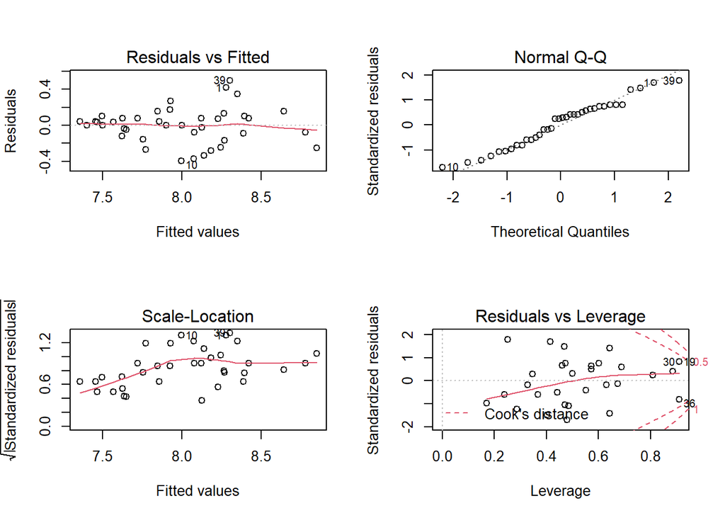

```r
par(mfrow = c(2,2))
plot(fit_OLS_drama_success)
```

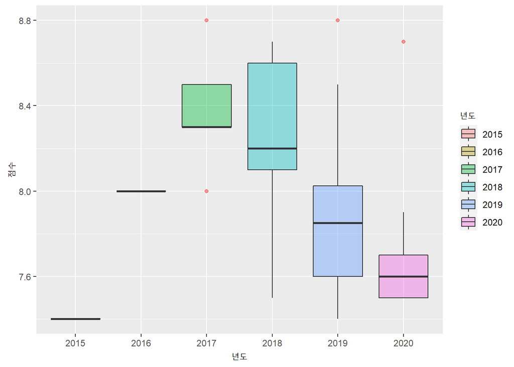

```r
ggplot(netflix_drama_success,aes(x=as.factor(Year),y=All_rating))+
  geom_boxplot(aes(fill=as.factor(Year)),outlier.colour = 'red',alpha=I(0.4))+
  xlab("년도") + ylab("점수") + labs(fill = "년도")
```

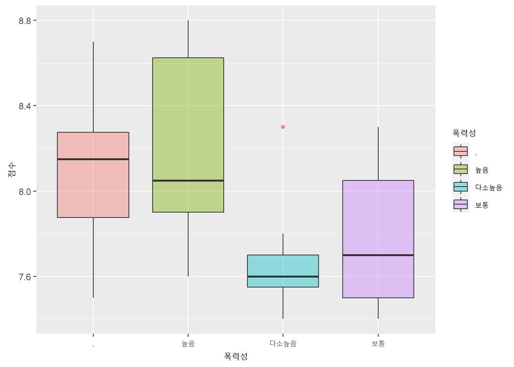

```r
ggplot(netflix_drama_success,aes(x=as.factor(Violence),y=All_rating))+
  geom_boxplot(aes(fill=as.factor(Violence)),outlier.colour = 'red',alpha=I(0.4))+
  xlab("폭력성") + ylab("점수") + labs(fill = "폭력성")
```

### 드라마 데이터(실패)

#### 세부 factor에서 유의한 값

```r
fit_OLS_drama_failure <- lm(All_rating ~ . , data=netflix_drama_failure)
summary(fit_OLS_drama_failure)
```

```
Call:
lm(formula = All_rating ~ ., data = netflix_drama_failure)

Residuals:
     Min       1Q   Median       3Q      Max
-0.75444 -0.05900  0.00441  0.14907  0.47694

Coefficients: (2 not defined because of singularities)
                        Estimate Std. Error t value Pr(>|t|)
(Intercept)             5.779349   0.471800  12.250 2.41e-07 ***
Mean_Length             0.001576   0.012343   0.128   0.9009
Director_max_award      0.021302   0.008786   2.425   0.0358 *
Year2018               -0.663517   0.395415  -1.678   0.1243
Year2019               -0.497257   0.362186  -1.373   0.1998
Harmful_themes높음      0.770991   0.625583   1.232   0.2460
Harmful_themes다소높음  0.518620   0.620640   0.836   0.4229
Harmful_themes보통      1.235946   0.488937   2.528   0.0300 *
Lewdness높음            0.640051   0.425831   1.503   0.1637
Lewdness다소높음              NA         NA      NA       NA
Lewdness보통           -0.478077   0.797960  -0.599   0.5624
Violence높음           -0.200326   0.568533  -0.352   0.7319
Violence다소높음       -0.028454   0.423016  -0.067   0.9477
Violence보통           -0.095520   0.319768  -0.299   0.7713
Fear높음                0.616521   0.556297   1.108   0.2937
Fear다소높음           -0.376254   0.486422  -0.774   0.4571
Fear보통                0.367321   0.385097   0.954   0.3627
Drugs높음              -0.664476   0.695032  -0.956   0.3616
Drugs다소높음           0.648451   0.585390   1.108   0.2939
Drugs보통                     NA         NA      NA       NA
Immatatable높음         0.594698   0.672585   0.884   0.3974
Immatatable다소높음     0.012247   0.649507   0.019   0.9853
Immatatable보통        -0.107886   0.556011  -0.194   0.8500
---
Signif. codes:  0 '***' 0.001 '**' 0.01 '*' 0.05 '.' 0.1 ' ' 1

Residual standard error: 0.3962 on 10 degrees of freedom
Multiple R-squared:  0.8544,    Adjusted R-squared:  0.5631
F-statistic: 2.933 on 20 and 10 DF,  p-value: 0.04181
```

#### 유의한 factor

```r
anova(fit_OLS_drama_failure)
```

```
Analysis of Variance Table

Response: All_rating
                   Df Sum Sq Mean Sq F value   Pr(>F)
Mean_Length         1 0.8527 0.85268  5.4322 0.041999 *
Director_max_award  1 0.2062 0.20618  1.3135 0.278444
Year                2 1.2796 0.63978  4.0759 0.050746 .
Harmful_themes      3 4.1269 1.37564  8.7639 0.003773 **
Lewdness            2 0.3384 0.16918  1.0778 0.376796
Violence            3 0.1387 0.04623  0.2945 0.828576
Fear                3 0.7850 0.26165  1.6669 0.236386
Drugs               2 1.1428 0.57141  3.6403 0.064895 .
Immatatable         3 0.3376 0.11253  0.7169 0.564138
Residuals          10 1.5697 0.15697
---
Signif. codes:  0 '***' 0.001 '**' 0.01 '*' 0.05 '.' 0.1 ' ' 1
```

#### 모델 유의성 확인

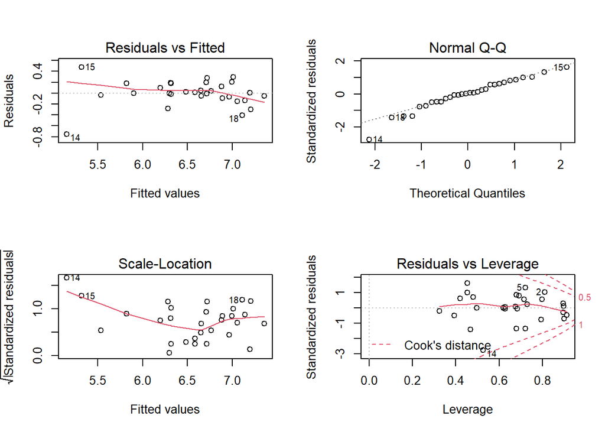

```r
par(mfrow = c(2,2))
plot(fit_OLS_drama_failure)
```

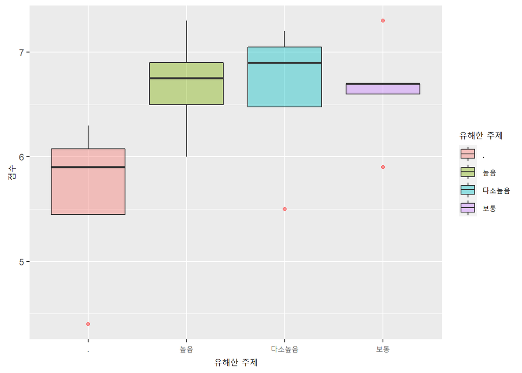

```r
ggplot(netflix_drama_failure,aes(x=as.factor(Harmful_themes),y=All_rating))+
  geom_boxplot(aes(fill=as.factor(Harmful_themes)),outlier.colour = 'red',alpha=I(0.4))+
  xlab("유해한 주제") + ylab("점수") + labs(fill = "유해한 주제")
```